# R avanzado. Sesión 1: Álgebra Lineal: matrices y sistema de ecuaciones

Autor/a

Afiliación

Jorge de la Vega

ITAM

Fecha de publicación

7 de octubre de 2025

# Temas a revisar en la sesión de hoy

Los temas que revisaremos en la sesión de hoy son los siguientes:

- Recordar algunas operaciones con matrices
- Solución de sistemas de ecuaciones
- Ejemplos de aplicación: Cadenas de Markov
- Ejemplos de aplicación: Portfolios de inversión
- Lectura de una Base de Datos.

Usaremos los siguientes paquetes:

- `matlib`: para algunas operaciones matriciales (resolución de ecuaciones)
- `igraph`: un paquete para dibujar gráficas (vértices y nodos)
- `markovchain`: cálculos y gráficas asociadas con Cadenas de Markov
- `curl`: peticiones vía HTTP/FTP
- `readxl`: importa archivos excel a R.

Los paquetes se cargarán en las secciones que se requieran, sólo para enfatizar la parte en donde se utiliza su funcionalidad.

## Vectores en R

Se pueden definir vectores de manera usual. En R los vectores, aunque se ven como renglones, internamente se consideran como vectores columna.

```r
u <- 1:6
v <- c(2,1,3,2,4,5)

# Vectores reales de datos
coneval <- read.csv("https://raw.githubusercontent.com/jvega68/MIDE-MyE/main/Datos/ConevalPobreza2016.csv")

# Estado es un "vector" de etiquetas, pero no es un vector real
Estado <- coneval$Estado  # es una variable con etiquetas.
Estado
```

```
 [1] "Aguscalientes"       "Baja California"     "Baja California Sur" "Campeche"            "Coahuila"
 [6] "Colima"              "Chiapas"             "Chihuahua"           "CDMX"                "Durango"
[11] "Guanajuato"          "Guerrero"            "Hidalgo"             "Jalisco"             "EdoMex"
[16] "Michoacán"           "Morelos"             "Nayarit"             "Nuevo León"          "Oaxaca"
[21] "Puebla"              "Querétaro"           "Qroo"                "SLP"                 "Sinaloa"
[26] "Sonora"              "Tabasco"             "Tamaulipas"          "Tlaxcala"            "Veracruz"
[31] "Yucatán"             "Zacatecas"
```

```r
# vector de valores
X1 <- coneval$Población.en.situación.de.pobreza.moderada
X1
```

```
 [1]  339.472  749.428  162.879  343.427  696.210  229.409 2615.325 1029.092 2279.296  593.734 2232.135 1489.506
[13] 1244.579 2415.711 7173.242 2130.519  850.469  370.779  706.274 1760.185 3166.336  575.963  401.855 1053.918
[25]  842.599  756.102  943.859 1052.622  627.033 3717.002  769.449  724.161
```

```r
names(X1) <- Estado  # Podemos poner nombres
X1
```

```
      Aguscalientes     Baja California Baja California Sur            Campeche            Coahuila              Colima
            339.472             749.428             162.879             343.427             696.210             229.409
            Chiapas           Chihuahua                CDMX             Durango          Guanajuato            Guerrero
           2615.325            1029.092            2279.296             593.734            2232.135            1489.506
            Hidalgo             Jalisco              EdoMex           Michoacán             Morelos             Nayarit
           1244.579            2415.711            7173.242            2130.519             850.469             370.779
         Nuevo León              Oaxaca              Puebla           Querétaro                Qroo                 SLP
            706.274            1760.185            3166.336             575.963             401.855            1053.918
            Sinaloa              Sonora             Tabasco          Tamaulipas            Tlaxcala            Veracruz
            842.599             756.102             943.859            1052.622             627.033            3717.002
            Yucatán           Zacatecas
            769.449             724.161
```

```r
X2 <- coneval$Población.en.situación.de.pobreza.extrema
names(X2) <- Estado
X2
```

```
      Aguscalientes     Baja California Baja California Sur            Campeche            Coahuila              Colima
             30.180              39.681              12.763              61.608              49.687              19.282
            Chiapas           Chihuahua                CDMX             Durango          Guanajuato            Guerrero
           1498.625             120.869             155.128              49.565             257.580             825.214
            Hidalgo             Jalisco              EdoMex           Michoacán             Morelos             Nayarit
            234.257             144.881            1056.958             435.343             115.383              99.351
         Nuevo León              Oaxaca              Puebla           Querétaro                Qroo                 SLP
             31.491            1087.156             561.866              59.717              69.185             213.810
            Sinaloa              Sonora             Tabasco          Tamaulipas            Tlaxcala            Veracruz
             87.084              75.325             284.233             103.598              74.724            1332.509
            Yucatán           Zacatecas
            132.415              56.113
```

```r
X1 + X2 # es la población en situación de pobreza (extrema o moderada)
```

```
      Aguscalientes     Baja California Baja California Sur            Campeche            Coahuila              Colima
            369.652             789.109             175.642             405.035             745.897             248.691
            Chiapas           Chihuahua                CDMX             Durango          Guanajuato            Guerrero
           4113.950            1149.961            2434.424             643.299            2489.715            2314.720
            Hidalgo             Jalisco              EdoMex           Michoacán             Morelos             Nayarit
           1478.836            2560.592            8230.200            2565.862             965.852             470.130
         Nuevo León              Oaxaca              Puebla           Querétaro                Qroo                 SLP
            737.765            2847.341            3728.202             635.680             471.040            1267.728
            Sinaloa              Sonora             Tabasco          Tamaulipas            Tlaxcala            Veracruz
            929.683             831.427            1228.092            1156.220             701.757            5049.511
            Yucatán           Zacatecas
            901.864             780.274
```

Se pueden hacer las operaciones usuales con vectores:

```r
u + v  # Suma (si tienen la misma longitud)
```

```
[1]  3  3  6  6  9 11
```

```r
2*u  # Multiplicación por un "escalar"
```

```
[1]  2  4  6  8 10 12
```

También se pueden hacer otras operaciones, pero es importante notar que estas no son parte de la definición matemática, sino del lenguaje:

```r
u*v   # producto componente a componente
```

```
[1]  2  2  9  8 20 30
```

```r
2 + v  # suma un escalar a un vector
```

```
[1] 4 3 5 4 6 7
```

```r
1:7 + v  # suma de vectores de diferente tamaño. Notar el warning
```

```
[1]  3  3  6  6  9 11  9
```

```r
z <- c("rojo","azul","verde")  # "vectores" de caractéres o palabras.
y <- c(1,2,3)
names(y) <- z   # vectores con nombres
```

Y podemos definir algunas de las funciones que definieron en clase

```r
# Producto punto:
producto.punto <- function(x,y){ sum(x*y)}
# Norma o longitud del vector (no confundir con length, que cuenta el número de
# componentes)
norma <- function(x){sqrt(sum(x*x))}
u <- c(1,3,4,2,4)
v <- c(7,3,56,2,1)
producto.punto(u,v)
```

```
[1] 248
```

```r
norma(u)
```

```
[1] 6.78233
```

Pra calcular el ángulo entre dos vectores:

```r
theta <- acos(producto.punto(u,v)/(norma(u)*norma(v))) #el ángulo en radianes

theta*(180/pi) # convierte radianes a grados (regla de tres: pi radianes = 180 grados, x radianes = a cuántos grados?
```

```
[1] 49.72209
```

```r
# Escribe una función que calcule el ángulo entre dos vectores y lo convierta a grados
```

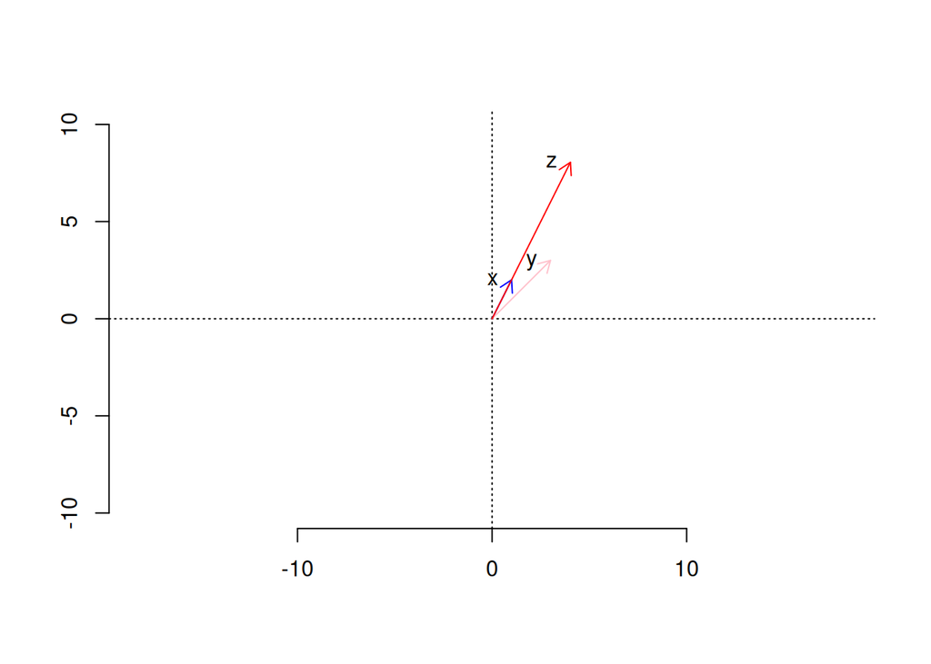

```r
# podemos crear una función  a la que le damos dos vectores x y y:
proy_yx <- function(x,y){(producto.punto(x,y)/norma(x))*x}
x <- c(1,2)
y <- c(3,3)
z <- proy_yx(x,y)

# graficamos
plot.new()
plot.window(xlim = c(-10,10),ylim = c(-10,10),asp = 1)
axis(side = 1)
axis(side = 2)
abline(h = 0, v = 0, lty = 3)
arrows(0,0,1,2, col = "blue", length = 0.1) # vector x
text(1,2,"x", pos = 2)
arrows(0,0,3,3, col = "pink", length = 0.1) # vector y
text(3,3,"y",pos  = 2)
arrows(0,0,z[1],z[2], col = "red", length = 0.1) # proyección de y en x
text(z[1],z[2],"z", pos = 2)
```

```r
norma(z) # longitud de z
```

```
[1] 9
```

¿Cuál es el ángulo entre $z$ y $y$?

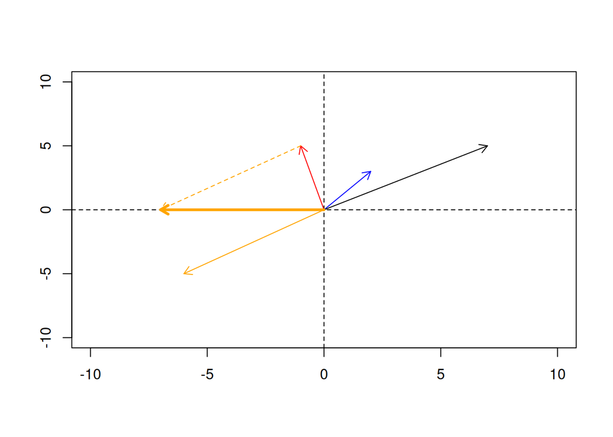

```r
plot(x = c(-10,10), y = c(-10,10), type="n", xlab="",ylab = "")
abline(h = 0,lty=2)
abline(v = 0,lty=2)
arrows(0,0,-1,5, col = "red", length=0.1)
arrows(0,0,2,3, col = "blue", length=0.1)
arrows(0,0,7,5, length=0.1)
arrows(0,0,-6,-5, col = "orange", length=0.1)
# agrega el vector naranja en la punta del vector rojo
arrows(-1,5,-6-1,5-5,lty=2,col="orange", length=0.1)
# agrega el vector suma de los vectores rojo y naranja
arrows(0,0,-6-1,5-5,lwd=3,col="orange", length=0.1)
```

Podemos hacer una función que sume vectores y los represente gráficamente.

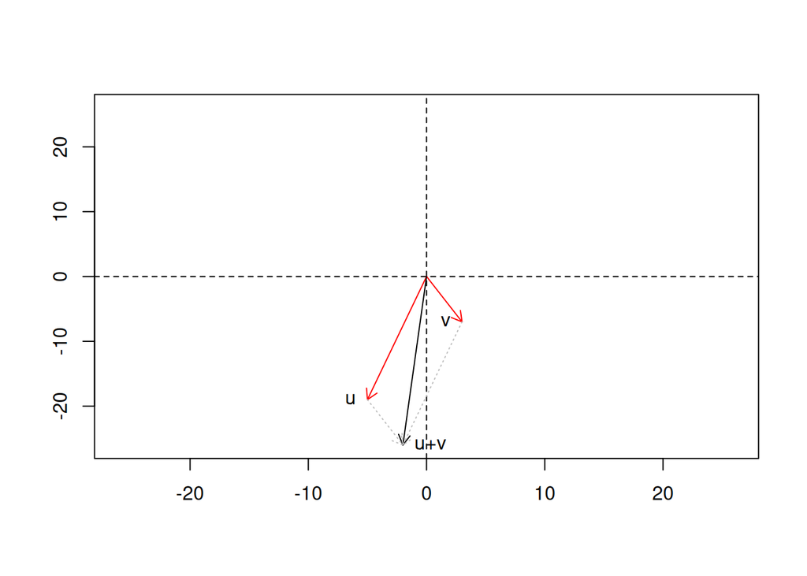

```
[1]  -2 -26
```

```r
graf_vectores <- function(u,v, sombra = T){
  z <- u+v
  # obtenemos coordenadas máxima y mínima
  max1 <- max(abs(u),abs(v),abs(z))
  plot(x = c(-max1, max1),
       y = c(-max1, max1), type="n", xlab="",ylab = "")
  abline(h = 0, lty = 2)
  abline(v = 0, lty = 2)
  arrows(0,0,u[1],u[2], col = "red", length=0.1)
  text(u[1],u[2],"u", pos = 2)
  arrows(0,0,v[1],v[2], col = "red", length=0.1)
  text(v[1],v[2],"v", pos = 2)
  arrows(0,0,z[1],z[2], length=0.1)
  text(z[1],z[2],"u+v", pos = 4)
  # Agregamos el vector en la punta del primer sumando
  if(sombra){
    arrows(u[1],u[2],z[1],z[2], col = "gray", lty=3, length = 0.1)
    arrows(v[1],v[2],z[1],z[2], col = "gray", lty=3, length = 0.1)
  }
  return(z)
}

# ejemplo
graf_vectores(c(-5,-19),c(3,-7), sombra = T)
```

## Matrices y sus operaciones

Ejemplos de matrices: diferentes maneras de construir matrices en R:

```r
# matriz con una constante
A <- matrix(0, nrow = 3, ncol = 4)
A[2,3] # correspnde a la entrada en renglón 2 y col 3
```

```
[1] 0
```

```r
dim(A)
```

```
[1] 3 4
```

```r
# crea una matriz a partir de un vector
(b <- c(1,0.7,-0.3,0.7,2,1,-0.3,1,8,0,2,1))
```

```
 [1]  1.0  0.7 -0.3  0.7  2.0  1.0 -0.3  1.0  8.0  0.0  2.0  1.0
```

```r
(dim(b) <- c(3,4))
```

```
[1] 3 4
```

```r
b
```

```
     [,1] [,2] [,3] [,4]
[1,]  1.0  0.7 -0.3    0
[2,]  0.7  2.0  1.0    2
[3,] -0.3  1.0  8.0    1
```

```r
(dim(b) <- c(4,3)) # llena por columna
```

```
[1] 4 3
```

```r
b
```

```
     [,1] [,2] [,3]
[1,]  1.0  2.0    8
[2,]  0.7  1.0    0
[3,] -0.3 -0.3    2
[4,]  0.7  1.0    1
```

```r
dim(b) <- NULL # regresa a vector
b
```

```
 [1]  1.0  0.7 -0.3  0.7  2.0  1.0 -0.3  1.0  8.0  0.0  2.0  1.0
```

```r
# Directamente con la función matriz
B1 <- matrix(c(1,3,5,7,9,11,2,4,6,8,10,12), nrow=4)
B2 <- matrix(c(1,3,5,7,9,11,2,4,6,8,10,12), nrow=4, byrow = TRUE)

# Matriz construida a partir de "pegar" vectores
u1 <- 1:10
u2 <- 11:20
u3 <- 21:30

(U <- rbind(u1,u2,u3)) # Matriz por renglones
```

```
   [,1] [,2] [,3] [,4] [,5] [,6] [,7] [,8] [,9] [,10]
u1    1    2    3    4    5    6    7    8    9    10
u2   11   12   13   14   15   16   17   18   19    20
u3   21   22   23   24   25   26   27   28   29    30
```

```r
(W <- cbind(u1,u2,u3)) # Matriz por columnas
```

```
      u1 u2 u3
 [1,]  1 11 21
 [2,]  2 12 22
 [3,]  3 13 23
 [4,]  4 14 24
 [5,]  5 15 25
 [6,]  6 16 26
 [7,]  7 17 27
 [8,]  8 18 28
 [9,]  9 19 29
[10,] 10 20 30
```

Operaciones con matrices

```r
A <- matrix(c(3,4,-1,0,2,5), nrow = 2) # 2x3
B <- matrix(c(3,6,4,4,-2,3), nrow = 3) # 3x2

# Producto de matrices
A %*% B
```

```
     [,1] [,2]
[1,]   11   20
[2,]   32   31
```

```r
B %*% A
```

```
     [,1] [,2] [,3]
[1,]   25   -3   26
[2,]   10   -6    2
[3,]   24   -4   23
```

```r
# Matriz identidad

I <- diag(1,nrow=3)
A %*% I
```

```
     [,1] [,2] [,3]
[1,]    3   -1    2
[2,]    4    0    5
```

```r
# Multiplicar un vector como matriz
b <- 1:3
dim(b) <- c(1,3)
b
```

```
     [,1] [,2] [,3]
[1,]    1    2    3
```

```r
b %*% B
```

```
     [,1] [,2]
[1,]   27    9
```

```r
c <- as.vector(b %*% B)
c
```

```
[1] 27  9
```

```r
# transpuesta
t(A)
```

```
     [,1] [,2]
[1,]    3    4
[2,]   -1    0
[3,]    2    5
```

```r
# inversa
A <- matrix(c(12,-4,7,6), nrow=2)
A
```

```
     [,1] [,2]
[1,]   12    7
[2,]   -4    6
```

```r
A1 <- solve(A) #función inversa
A %*% A1
```

```
             [,1]         [,2]
[1,] 1.000000e+00 8.326673e-17
[2,] 5.551115e-17 1.000000e+00
```

```r
#Podemos redondear
round(A%*% A1,2)
```

```
     [,1] [,2]
[1,]    1    0
[2,]    0    1
```

```r
A1 %*% A
```

```
     [,1]          [,2]
[1,]    1 -5.551115e-17
[2,]    0  1.000000e+00
```

```r
# número de condición de la matriz. Cercano a 1 es ideal. Mientras más grande, peor condicionada.
kappa(A)
```

```
[1] 1.825
```

```r
# Determinante (sólo matrices cuadradas)
A <- matrix(c(1,2,3,4), nrow=2)
det(A)
```

```
[1] -2
```

### Matrices triangulares:

```r
(C <- B %*% A)
```

```
     [,1] [,2]
[1,]   11   25
[2,]    2   10
[3,]   10   24
```

```r
(C2 <- C)
```

```
     [,1] [,2]
[1,]   11   25
[2,]    2   10
[3,]   10   24
```

```r
C2[upper.tri(C)] <- 0 # se incluye la diagonal con diag=T
C2
```

```
     [,1] [,2]
[1,]   11    0
[2,]    2   10
[3,]   10   24
```

### Factorización de matrices

#### Vectores y valores propios para matrices cuadradas

También podemos obtener los eigenvalores y eigenvectores de una matriz cuadrada(también conocida como valores y vectores propios). Esto se conoce como descomposición espectral y es muy utilizada en todas partes.

```r
# Ejemplo de matriz de Hilbert de dimensión 3:
(H3 <- matrix(c(1, 1/2, 1/3, 1/2, 1/3, 1/4, 1/3, 1/4, 1/5), nrow = 3))
```

```
          [,1]      [,2]      [,3]
[1,] 1.0000000 0.5000000 0.3333333
[2,] 0.5000000 0.3333333 0.2500000
[3,] 0.3333333 0.2500000 0.2000000
```

```r
eigen(H3)
```

```
eigen() decomposition
$values
[1] 1.40831893 0.12232707 0.00268734

$vectors
          [,1]       [,2]       [,3]
[1,] 0.8270449  0.5474484  0.1276593
[2,] 0.4598639 -0.5282902 -0.7137469
[3,] 0.3232984 -0.6490067  0.6886715
```

Otra descomposición es la descomposición en valor singular, que aplica a cualquier matriz rectangular. Descompone la matriz $X=UDV'$, donde $U$ y $V$ son matrices ortogonales ($U'U=I$)

```r
A <- matrix(c(2,3,-2,1,0,-1,4,-1,1,1,1,1), nrow = 4)
svd(A)
```

```
$d
[1] 5.4844283 3.0531765 0.7740542

$u
           [,1]       [,2]        [,3]
[1,] -0.2701421 -0.5466043  0.18168345
[2,] -0.5275885 -0.5270922  0.25074258
[3,]  0.7596438 -0.6246531 -0.09455304
[4,] -0.2676096 -0.1822254 -0.94613900

$v
            [,1]       [,2]       [,3]
[1,] -0.71291787 -0.5264695  0.4632256
[2,]  0.69902882 -0.5860437  0.4097701
[3,] -0.05573896 -0.6159405 -0.7858184
```

La factorización de Cholesky, que aplica a marices definidas positivas, simétricas X. En este caso, se obtiene $X=Q'Q$ donde $Q$ es una matriz triangular superior

```r
X <-  matrix(rnorm(200),nrow = 40)
Sigma <- cov(X) # matriz de covarianzas, es definida positiva
(Q <- chol(Sigma))
```

```
          [,1]       [,2]       [,3]      [,4]          [,5]
[1,] 0.8944978 0.06488465 0.05078107 0.1932983  0.0002002286
[2,] 0.0000000 0.82770103 0.14270658 0.2211080 -0.0450990962
[3,] 0.0000000 0.00000000 0.95989428 0.1787425  0.0340805908
[4,] 0.0000000 0.00000000 0.00000000 0.9120898  0.2710098989
[5,] 0.0000000 0.00000000 0.00000000 0.0000000  0.9467557806
```

```r
t(Q) %*% Q # recuperamos Sigma
```

```
             [,1]        [,2]       [,3]      [,4]          [,5]
[1,] 0.8001262905  0.05803917 0.04542356 0.1729049  0.0001791041
[2,] 0.0580391740  0.68929901 0.12141329 0.1955534 -0.0373155765
[3,] 0.0454235590  0.12141329 0.94434091 0.2129433  0.0262879942
[4,] 0.1729049182  0.19555341 0.21294334 0.9501097  0.2433439523
[5,] 0.0001791041 -0.03731558 0.02628799 0.2433440  0.9729883286
```

# Sistemas de ecuaciones

Como vieron en las lecciones del módulo, las matrices están muy relacionadas con los sistemas de ecuaciones lineales. Por ejemplo, las ecuaciones:

$$\begin{eqnarray}
x_1 + 3x_2 & = & 7 \\
2x_1 + 4x_2 &= & 10
\end{eqnarray}$$

Se puede escribir de la forma:

$$\begin{eqnarray}
\begin{pmatrix} 1 & 3 \\ 2 & 4 \end{pmatrix} \begin{pmatrix} x_1 \\ x_2 \end{pmatrix} & = &
\begin{pmatrix} 7 \\ 10 \end{pmatrix}
\end{eqnarray}$$

```r
A <- matrix(c(1,2,3,4),nrow=2)
b <- c(7,10)
x <- solve(A) %*% b # manera ineficiente
x
```

```
     [,1]
[1,]    1
[2,]    2
```

```r
solve(A,b) # forma eficiente: utiliza un algoritmo mucho más eficiente
```

```
[1] 1 2
```

Hay tres posibles casos de soluciones para sistemas de ecuaciones:

- Exactamente una solución
- No soluciones
- Infinitas Soluciones

Ver si el siguiente sistema es inconsistente:

$$\begin{eqnarray}
x + y + 2z & = & 3 \\
-x + 3y - 5z & = & 7 \\
2x - 2y + 7z & = & 1 \\
\end{eqnarray}$$

```r
library(matlib) # funciones para resolver sistemas lineales

# Ejemplo de un sistema sin solución
A  <- matrix(c(1, 1, 2, -1, 3, -5, 2, -2, 7), nrow = 3, byrow = T)
b  <- c(3,7,1)
gaussianElimination(A, b)
```

```
     [,1] [,2]  [,3]  [,4]
[1,]    1    0  2.75  4.25
[2,]    0    1 -0.75  3.75
[3,]    0    0  0.00 -5.00
```

Resolver:

$$\begin{eqnarray}
-x + 2y + 3z & = & 0 \\
x - 4y - 13z & = & 0 \\
-3x + 5y + 4z & = & 0 \\
\end{eqnarray}$$

```r
A <- matrix(c(-1,2,3,1,-4,-13,-3,5,4), nrow = 3, byrow = TRUE)
b <- c(0,0,0)
gaussianElimination(A,b)
```

```
     [,1] [,2] [,3] [,4]
[1,]    1    0    7    0
[2,]    0    1    5    0
[3,]    0    0    0    0
```

¿Cuál es la solución?

Resolver el siguiente sistema usando la eliminación gaussiana:

```r
A <- matrix(c(1,-1, 2, 0, 3,
             -1, 1, 0, 2,-5,
              1,-1, 4, 2, 4,
             -2, 2,-5,-1,-3), nrow = 4, byrow = TRUE)
b <- c(1,5,13,-1)
gaussianElimination(A,b)
```

```
     [,1] [,2] [,3] [,4] [,5] [,6]
[1,]    1   -1    0   -2    0  -15
[2,]    0    0    1    1    0    5
[3,]    0    0    0    0    1    2
[4,]    0    0    0    0    0    0
```

# Cadenas de Markov

Supongamos un juego con tablero circular con celdas marcadas del 1 al 10. Comenzando con $X_0=1$, se lanza un dado y se avanza ese número de casillas. Sea $X_n=$ número de la casilla en el $n$-ésimo movimiento

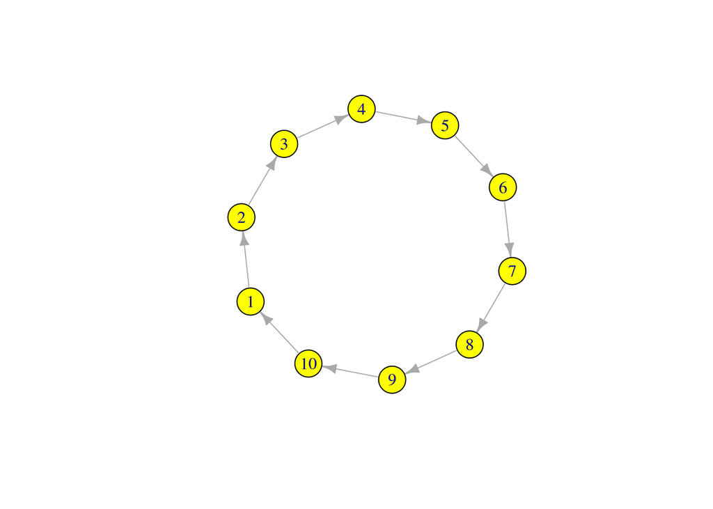

```r
library(igraph)
g <- graph(edges = c(1,2,2,3,3,4,4,5,5,6,6,7,7,8,8,9,9,10,10,1),
           n = 10,
           directed = T)
plot(g, edge.arrow.size = 0.7, vertex.size = 20, vertex.color = "yellow")
```

La matriz de probabilidades de transición está dada por:

$$P = \begin{pmatrix}
0 & 1/6 & 1/6 & 1/6 & 1/6 & 1/6 & 1/6 & 0 & 0 & 0 \\
0 & 0 & 1/6 & 1/6 & 1/6 & 1/6 & 1/6 & 1/6 & 0 & 0 \\
0 & 0 & 0 & 1/6 & 1/6 & 1/6 & 1/6 & 1/6 & 1/6 & 0 \\
0 & 0 & 0 & 0 & 1/6 & 1/6 & 1/6 & 1/6 & 1/6 & 1/6 \\
1/6 & 0 & 0 & 0 & 0 & 1/6 & 1/6 & 1/6 & 1/6 & 1/6 \\
1/6 & 1/6 & 0 & 0 & 0 & 0 & 1/6 & 1/6 & 1/6 & 1/6 \\
1/6 & 1/6 & 1/6 & 0 & 0 & 0 & 0 & 1/6 & 1/6 & 1/6 \\
1/6 & 1/6 & 1/6 & 1/6 & 0 & 0 & 0 & 0 & 1/6 & 1/6 \\
1/6 & 1/6 & 1/6 & 1/6 & 1/6 & 0 & 0 & 0 & 0 & 1/6 \\
1/6 & 1/6 & 1/6 & 1/6 & 1/6 & 1/6 & 0 & 0 & 0 & 0
\end{pmatrix}$$

```r
P <- matrix(c(0,rep(c(rep(1/6,6),rep(0,5)),3),
            rep(c(rep(1/6,7),rep(0,4)),6)), nrow=10, byrow=T)
```

Matriz de transición de 2 lanzamientos

```r
P2 <- P %*% P
P3 <- P2 %*% P
```

Creamos una función que pueda hacer el producto de la misma matriz un número $n$ de veces:

```r
simulaciones <- function(n,Q){
  R <- Q
  for(i in 1:n) R <- R %*% Q
  return(R)
}

W <- simulaciones(300,P)  # ejecuta 300 iteraciones del juego.
```

## problema de inventario

Se considera un almacén que tiene un sólo producto y los siguientes supuestos:

- Cuando no hay el producto, las personas va a otro lado.
- Llamamos $X_n$ como el número de artículos en el almacén al inicio del periodo $n$
- El nivel del inventario máximo es 5

Entonces, los posibles niveles del inventario son: 2,3,4 o 5.

```r
library(markovchain)
P <- matrix(c(0.0498,0.1494,0.2240,0.224,
              0,0.0498,0.1494,0.2240,
              0,0,0.0498,0.1494,
              0.9502,0.8008,0.5768,0.4026),nrow= 4)
rownames(P)<- colnames(P) <- as.character(2:5)
inventario <- new("markovchain", states  = as.character(2:5),
                  transitionMatrix = P, name = "Inventario")
steadyStates(inventario)
```

```
            2         3          4        5
[1,] 0.181211 0.1504296 0.09080838 0.577551
```

Una gráfica:

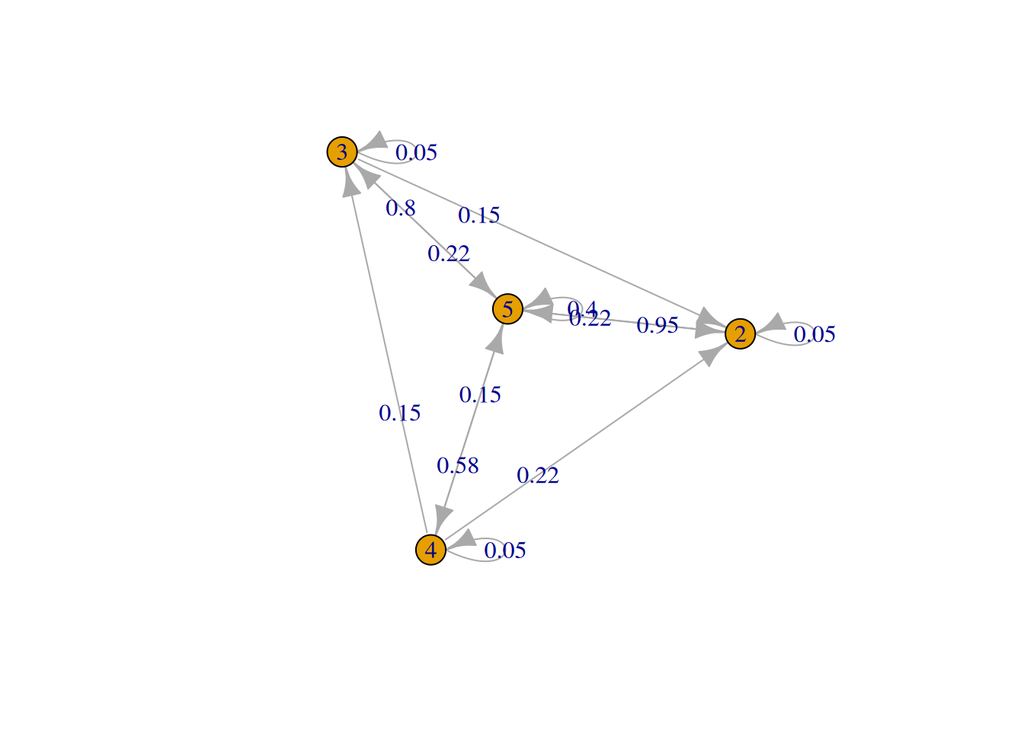

```r
plot(inventario)
```

# Modelo de portafolios de inversión

Consideremos un portafolio con tres activos, denotados por A, B y C. Supongan que los activos tienen medias y desviaciones estándar dados por los siguientes vector y matriz de datos mensuales.

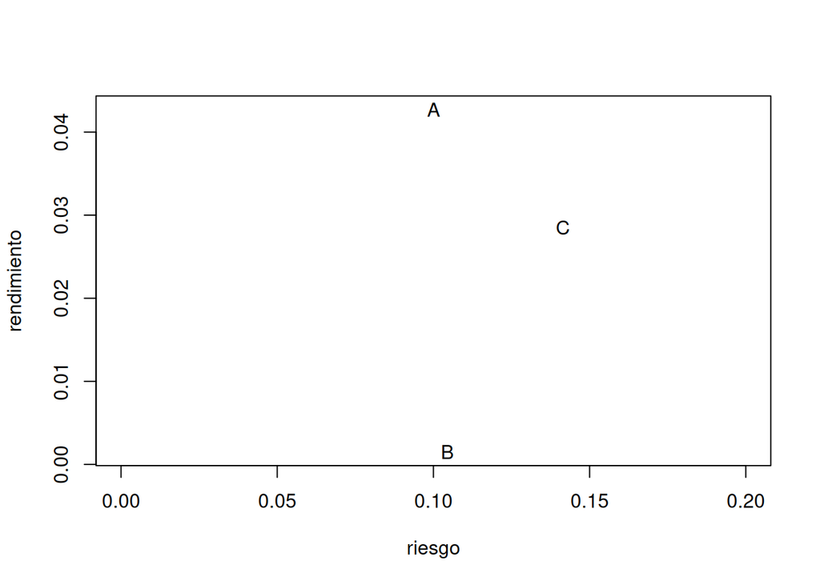

```r
acciones <- c("A","B","C")
rend <- c(0.0427,0.0015,0.0285)
covas <- matrix(c(0.01,0.0018,0.0011,
                  0.0018,0.0109,0.0026,
                  0.0011,0.0026,0.02), nrow = 3)
plot(sqrt(diag(covas)),rend,
     pch = acciones, xlim=c(0,0.2),
     xlab="riesgo", ylab="rendimiento")
```

Supongamos que $x_i$ es la proporción de la riqueza que se invierte en el instrumento $i$.

```r
p1 <- c(0.2,0.5,0.3) # proporciones de inversión
```

El rendimiento y riesgo del portafolio son entonces:

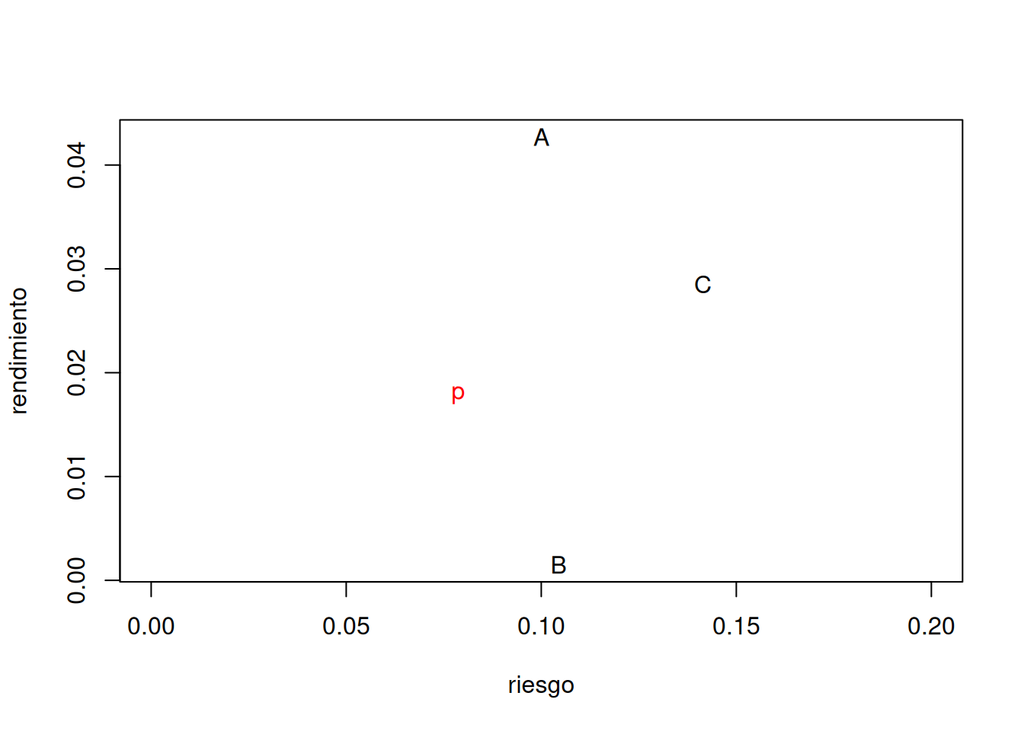

```r
# recordar la definición de producto punto:
producto.punto <- function(x,y) sum(x*y)

rend_p1 <- producto.punto(p1,rend)
sd_p1 <- as.numeric(sqrt(p1 %*% covas %*% p1))
plot(sqrt(diag(covas)),rend,
     pch = acciones, xlim=c(0,0.2),
     xlab="riesgo", ylab="rendimiento")
points(sd_p1,rend_p1,pch ="p",col="red")
```

Podemos seguir añadiendo portafolios,

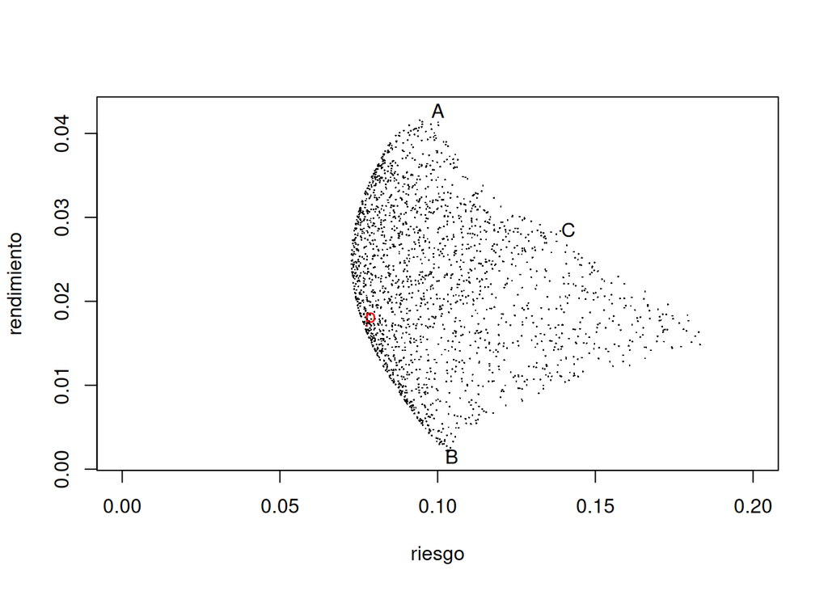

```r
n <- 2000

z <- matrix(0,nrow=n,ncol=3) #matriz de portafolios

z[,1] <- runif(n)
z[,2] <- runif(n)
z[,3] <- 1-z[,1]-z[,2]

# Para cada portafolio calcular su media y su varianza
rend_z <- apply(z,1,function(x)sum(x*rend))
sd_z <- apply(z,1,function(x)as.numeric(sqrt(x %*% covas %*% x)))

plot(sqrt(diag(covas)), rend,
     pch = acciones, xlim=c(0,0.2),
     xlab="riesgo", ylab = "rendimiento")

points(sd_p1,rend_p1,pch ="p",col = "red")
points(sd_z, rend_z, pch = 16, cex = 0.2)
```

- Otras funciones importantes que se aplican a las matrices y a los data frames: `apply`, `tapply`. Más adelante veremos otros ejemplos de este tipo de funciones, que son `lapply`, `sapply` y `mapply`.
- Ejemplos de modelo de Leontief de Insumo-Producto
- Modelo de portafolios de Markowitz
- Otros ejemplos de cadenas de Markov (si da tiempo)

# Otras funciones poderosas para matrices

## Función apply

Esta función permite aplicar alguna función a una matriz ya sea por renglones o por columnas

```r
set.seed(1) #fijar la semilla de números aleatorios
X <- matrix(sample(x = 1:20, size = 20, replace = F),nrow=5)
apply(X,MARGIN = 1,mean) #calcula los promedios de cada renglón
```

```
[1] 14.00  8.75  9.25 13.00  7.50
```

```r
apply(X,MARGIN = 2,max)  #calcular el máximo de cada columna
```

```
[1] 13 19 18 20
```

```r
Y <- cbind(X,apply(X,MARGIN = 1,sum))
colnames(Y) <- c("A","B","C","D","Total")
```

## Función tapply

La función `tapply` permite aplicar una función a un vector, por grupos indicados por una o varias variables que etiquetan a los grupos.

```r
y <- sample(1:100,50,F)
etiquetas <- rep(c("A","B","C","D"),c(20,10,5,15))
tapply(y,etiquetas,function(x)max(x)-min(x))
```

```
 A  B  C  D
80 82 63 81
```

## Ejemplo grandote: Asegurados del IMSS

Veamos los datos de los asegurados por Entidad Federativa al mes de agosto de 2020. Los datos se encuentran en los datos del curso, pero se pueden bajar directamente de la página del IMSS. La ubicación del archivo está en http://datos.imss.gob.mx/sites/default/files/asg-2020-08-31.csv. Adicionalmente, para entender la estructura de datos, se requiere estudiar el diccionario de datos que se encuentra en la siguiente ubicación: http://datos.imss.gob.mx/sites/default/files/diccionario_de_datos_1.xlsx:

```r
# file.choose()
#datos <- read.delim(file = "http://datos.imss.gob.mx/sites/default/files/asg-2020-08-31.csv",
#                    fileEncoding = "ISO-8859-1",
#                    sep = "|")
datos <- read.delim(file = unzip("asg-2020-08-31.zip"),
                    fileEncoding = "ISO-8859-1",
                    sep = "|")
# También cargamos el diccionario para tomar información de éste
library(readxl)  # Para leer archivos de Excel
library(curl)   # Para bajar archivos temporales de un url
temp <- curl_download("http://datos.imss.gob.mx/sites/default/files/diccionario_de_datos_1.xlsx",
                      destfile = "temp.xlsx" )
dicc <- read_xlsx("temp.xlsx", sheet = "entidad-municipio", skip = 1)

entidades <- data.frame(
  cve_entidad = as.integer(unique(dicc$cve_entidad)),
      entidad = unique(dicc$`descripción entidad`))
# Unimos las tablas por la clave de entidad para agregar el nombre de la entidad a los datos
datos <- merge(x = datos, y = entidades, by = "cve_entidad")
```

Este conjunto de datos NO es una matriz, sino un *data.frame*, pues tiene algunas columnas que no son múmeros, sino etiquetas, por ejemplo, las claves de los municipios. Vamos a formar una matriz tomando algunos campos numéricos y viendo cómo aplicar algunas funciones.

Del diccionario de datos, vemos las siguientes definiciones:

- `sexo`: variable que indica si es hombre (1) o mujer (2). Aunque es numérica, en realidad es una etiqueta
- `cve_entidad`: identificador de la Entidad Federativa. Aunque es numérica, es una etiqueta.
- `asegurados`: Número de asegurados.
- `no_trabajadores`: Asegurados sin un empleo asociado
- `teu`: puestos de trabajo eventuales urbanos
- `tec`: puestos de trabajo eventuales del campo
- `tpu`: puestos de trabajo permanentes urbanos
- `tpc`: puestos de trabajo permanentes del campo

```r
sexo <- datos$sexo
asegurados <- datos[,c("asegurados","no_trabajadores")]
entidad <- datos[,"entidad"]
puestos_trabajo <- datos[,c("teu","tec","tpu","tpc")]
masa_salarial <- datos[,c("masa_sal_ta","masa_sal_teu","masa_sal_tec","masa_sal_tpu","masa_sal_tpc")]
puestos_trabajo[sample(1:nrow(puestos_trabajo),20),] # muestrea 20 renglones del data frame
```

```
        teu tec tpu tpc
3145249   2   0   1   0
2897557   0   0   3   0
1997414   0   0   4   0
1087817   0   0   1   0
3086955   0   0   1   0
4170718   0   0   3   0
3896371   0   0   1   0
628865    0   0   1   0
2757563   0   0   6   0
1680527   0   0   3   0
3774749   0   0   1   0
1541802   0   0   1   0
3113461   0   0   4   0
2507288   1   0   1   0
3437532   5   0   0   0
2782209   1   0   1   0
1846862   0   0   3   0
1381190   0   0   1   0
1783412   3   0   0   0
3983278   0   0   1   0
```

¿Cuántos registros por entidad se tienen?

```r
(A <- table(datos$entidad)) # Número de registros por cada entidad
```

```
                 Aguascalientes                 Baja California             Baja California Sur
                          74854                          176430                           42870
                       Campeche                         Chiapas                       Chihuahua
                          30556                           55394                          185712
               Ciudad de México            Coahuila de Zaragoza                          Colima
                         505671                          165847                           37347
                        Durango                   Estado México                      Guanajuato
                          56081                          412281                          216647
                       Guerrero                         Hidalgo                         Jalisco
                          45165                           73017                          426145
            Michoacán de Ocampo                         Morelos                         Nayarit
                         121345                           58644                           38835
                     Nuevo León                          Oaxaca                          Puebla
                         405250                           59509                          155909
                      Querétaro                    Quintana Roo                 San Luis Potosí
                         143442                           62026                          112026
                        Sinaloa                          Sonora                         Tabasco
                         115948                          152492                           43579
                     Tamaulipas                        Tlaxcala Veracruz de Ignacio de la Llave
                         146823                           32389                          191368
                        Yucatán                       Zacatecas
                          76567                           52343
```

¿Cómo obtenemos el total de puestos de trabajo?

```r
Total_puestos_trabajo <- apply(puestos_trabajo, 2, sum)
```

Si queremos obtener el total de trabajos por entidad federativa y también separado por hombres y mujeres?

```r
total_por_delegacion <- apply(puestos_trabajo, 1, sum)
# el paréntesis externo es para que imprima el resultado en pantalla cuando termina
(puestos_por_entidad <- tapply(total_por_delegacion,entidad,sum))
```

```
                 Aguascalientes                 Baja California             Baja California Sur
                         323153                          915557                          167538
                       Campeche                         Chiapas                       Chihuahua
                         123878                          218178                          897690
               Ciudad de México            Coahuila de Zaragoza                          Colima
                        3251617                          750871                          133853
                        Durango                   Estado México                      Guanajuato
                         236944                         1586644                          973738
                       Guerrero                         Hidalgo                         Jalisco
                         144572                          218985                         1758496
            Michoacán de Ocampo                         Morelos                         Nayarit
                         448497                          201939                          143936
                     Nuevo León                          Oaxaca                          Puebla
                        1589977                          206982                          586731
                      Querétaro                    Quintana Roo                 San Luis Potosí
                         587463                          356310                          436384
                        Sinaloa                          Sonora                         Tabasco
                         529692                          601240                          171299
                     Tamaulipas                        Tlaxcala Veracruz de Ignacio de la Llave
                         665498                           99667                          715225
                        Yucatán                       Zacatecas
                         360933                          184855
```

```r
(puestos_por_entidad_y_sexo <- tapply(total_por_delegacion, list(entidad, sexo), sum))
```

```
                                      1       2
Aguascalientes                   204040  119113
Baja California                  537487  378070
Baja California Sur              107856   59682
Campeche                          85227   38651
Chiapas                          137553   80625
Chihuahua                        528380  369310
Ciudad de México                1902545 1349072
Coahuila de Zaragoza             486503  264368
Colima                            82799   51054
Durango                          152374   84570
Estado México                    996391  590253
Guanajuato                       605463  368275
Guerrero                          89447   55125
Hidalgo                          138788   80197
Jalisco                         1068525  689971
Michoacán de Ocampo              276254  172243
Morelos                          119583   82356
Nayarit                           88159   55777
Nuevo León                      1040859  549118
Oaxaca                           127417   79565
Puebla                           369260  217471
Querétaro                        358506  228957
Quintana Roo                     228524  127786
San Luis Potosí                  268527  167857
Sinaloa                          324487  205205
Sonora                           365728  235512
Tabasco                          118561   52738
Tamaulipas                       409455  256043
Tlaxcala                          61085   38582
Veracruz de Ignacio de la Llave  444295  270930
Yucatán                          230962  129971
Zacatecas                        116541   68314
```

Si queremos ver los resultados en miles, tenemos que dividir cada renglón por 1000:

```r
puestos_por_entidad_y_sexo <- tapply(total_por_delegacion,list(entidad,sexo),
                                      function(x)sum(x)/1000)
colnames(puestos_por_entidad_y_sexo) <- c("H","M")
(X <- puestos_por_entidad_y_sexo)
```

```
                                       H        M
Aguascalientes                   204.040  119.113
Baja California                  537.487  378.070
Baja California Sur              107.856   59.682
Campeche                          85.227   38.651
Chiapas                          137.553   80.625
Chihuahua                        528.380  369.310
Ciudad de México                1902.545 1349.072
Coahuila de Zaragoza             486.503  264.368
Colima                            82.799   51.054
Durango                          152.374   84.570
Estado México                    996.391  590.253
Guanajuato                       605.463  368.275
Guerrero                          89.447   55.125
Hidalgo                          138.788   80.197
Jalisco                         1068.525  689.971
Michoacán de Ocampo              276.254  172.243
Morelos                          119.583   82.356
Nayarit                           88.159   55.777
Nuevo León                      1040.859  549.118
Oaxaca                           127.417   79.565
Puebla                           369.260  217.471
Querétaro                        358.506  228.957
Quintana Roo                     228.524  127.786
San Luis Potosí                  268.527  167.857
Sinaloa                          324.487  205.205
Sonora                           365.728  235.512
Tabasco                          118.561   52.738
Tamaulipas                       409.455  256.043
Tlaxcala                          61.085   38.582
Veracruz de Ignacio de la Llave  444.295  270.930
Yucatán                          230.962  129.971
Zacatecas                        116.541   68.314
```

Podemos hacer una gráfica

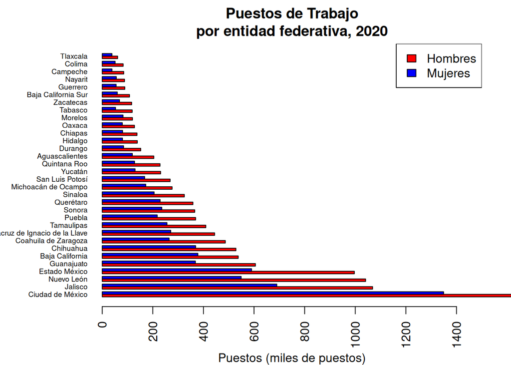

```r
par(mar = c(4,7,3,2)) # b,l,t,r

barplot(t(X[order(X[,"H"],decreasing = T),]),
        cex.names = 0.6,
        xlab = "Puestos (miles de puestos)",
        beside = T,
        las = 2,
        horiz = T,
        xlim = c(0,1500),
        col = c("red","blue"),
        main = "Puestos de Trabajo\npor entidad federativa, 2020")
legend("topright",legend = c("Hombres","Mujeres"), col = c("red","blue"), fill = c("red","blue"))
```

Masas salariales por entidad y por sexo y entidad

```r
aggregate(masa_salarial, by = list(entidad), sum)
```

```
                           Group.1 masa_sal_ta masa_sal_teu masa_sal_tec masa_sal_tpu masa_sal_tpc
1                   Aguascalientes   128898867      8106184    271022.13    119418418   1103243.00
2                  Baja California   382025015     23509354   6191823.83    350984214   1339624.00
3              Baja California Sur    61736928     13228758   2299563.67     45690318    518288.37
4                         Campeche    55696574     10249549    288349.50     44931877    226799.24
5                          Chiapas    74114540      7325908    536453.54     65503679    748498.69
6                        Chihuahua   351966803     28468847    983874.08    320074919   2439162.30
7                 Ciudad de México  1635986110    184388135       257.58   1451595736      1981.45
8             Coahuila de Zaragoza   303121358     31258053    812969.02    268473226   2577110.14
9                           Colima    46972085      8608194    370923.19     37094639    898328.40
10                         Durango    75291087      7130281    104985.01     67656821    399000.46
11                   Estado México   605638110     84901304    447156.68    519835080    454569.62
12                      Guanajuato   337942183     40479613   2708580.58    288380603   6373386.21
13                        Guerrero    46991292      8024160     66742.54     38862214     38175.66
14                         Hidalgo    74464013     13666158     45712.60     60374711    377431.37
```

[output cut: 18 more lines]

Podemos escribir las tablas resumen a archivos

```r
D <- aggregate(masa_salarial, by = list(entidad,sexo),function(x)sum(x)/1000)
write.csv(D,"salida_masas.csv")
```